# Data Wrangling with NYC Trip Record Data

April 29, 2019

## Background

### Exploring the gig economy

- The U.S. workforce is increasingly participating in what is known as the “gig economy”
- The gig economy allows workers to easily find quick, temporary jobs
- While these new labor models create more income opportunities, how do they impact or disrupt current industries and labor markets?
- For our project, we proposed examining the impact of the gig economy through a case study using data provided by New York City’s Taxi & Limousine Commission (TLC)

## Background

NYC’s TLC published .csv files on trip record data

[figure not shown]

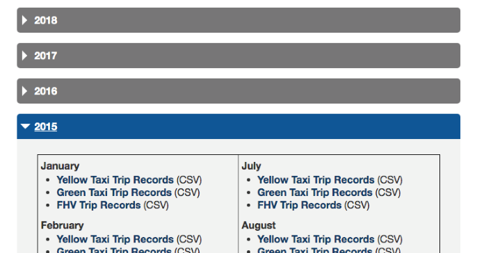

## Research Design/Approach

- Build our own consolidated dataset using trip record data from the TLC using data wrangling techniques from `tidyverse` (`dplyr` and `tidyr` grammar) and `purrr` packages. This involved taking the data from:

```
    raw -> processed
    altering the unit of analysis
```

- Once we had the dataset together, we planned to conduct some exploratory data analysis (EDA) using ‘ggplot2’ from the tidyverse package and potentially look at relationships between green/yellow taxis versus FHV’s as they began to enter the market
- We realized quickly though that the data was constructed for a different purpose and that most of our time would be spent building a dataset that could be used for our analysis

## Research Design/Approach

Huge file sizes

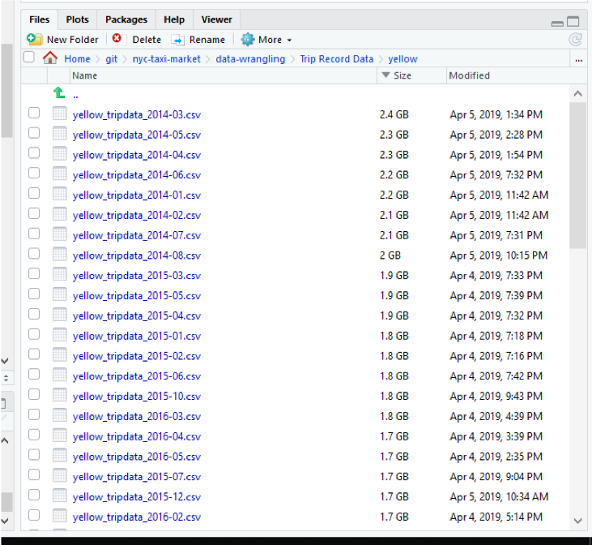

## Methods and Tools

We used functions from several packages including `readr`, `tidyverse`, `recipes`, `plyr`, and base R.

- Data processing and cleaning
  - 1 Read the data in using `readr`*
  - 2 Select and rename relevant variables using `select` and `add_column` to create new variables
  - 3 Mutate and transform variables
  - 4 Aggregate data up to a month (altering unit of analysis)
  - 5 Combine all files (month and vehicle type) using `list.files` and `plyr`
- Exploratory Data Analysis
  - Once our data set was built, we were finally able to begin exploring the data with `ggplot2`

## Methods and Tools

| Variables | Aggregation |
| --- | --- |
| pickup_date | Rounded to month, year |
| dropoff_date | Rounded to month, year |
| passenger_count | Mean of passenger count |
| payment type factor variables | Sum of each factor variable |
| trip_distance | Mean of trip distance |
| total_fare | Mean of total fare |
| trip | Mode of trip |
| trip_n | Count (# of trips by month) |

## Methods and Tools

We used `group_by` to aggregate the data up to a month which also meant that we needed to `summarise` all of our variables at that level.

```
    yellow_monthly <- yellow_clean %>%
      mutate(pickup_date = round_date(pickup_date, unit = "month"),
             dropoff_date = round_date(dropoff_date, unit = "month")) %>%
      group_by(month, year, vehicle_type) %>%
      summarise(mean_passenger_count= mean(passenger_count),
                payment_credit = sum(payment_credit),
                payment_cash = sum(payment_cash),
                payment_no_charge = sum(payment_no_charge),
                payment_dispute = sum(payment_dispute),
                mean_trip_distance = mean(trip_distance),
                mean_total_fare = mean(total_fare),
                trip = mode(trip),
                trip_n = n()) %>%
      na.omit() %>%
      filter(year==2018 & month==1)`
```

## Results

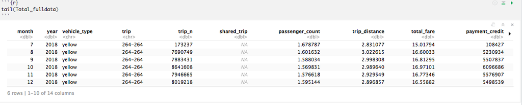

## Results

Once our data set was built, we began plotting and exploring the data

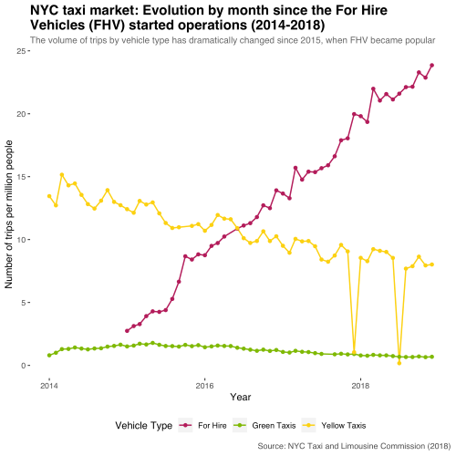

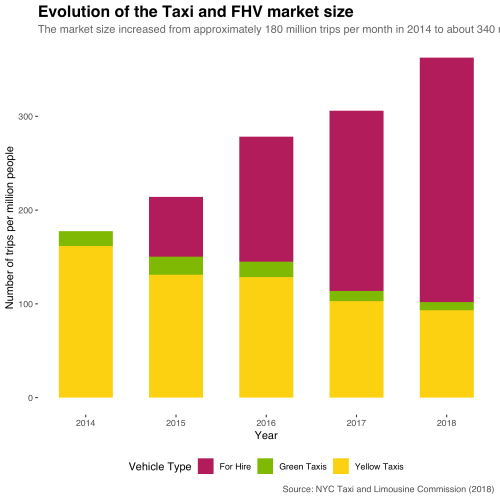

## Results

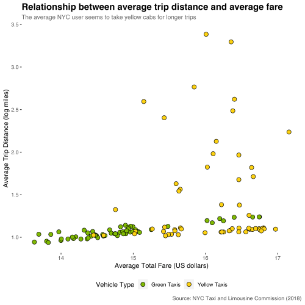

## Results

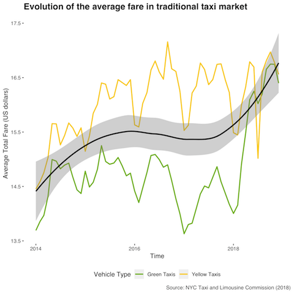

## Next steps for future work

Our project presented many challenges related to file sizes, missing data, incomplete or inaccurate data, and also inconsistent variables across files.

- FHVs did not collect the same information as yellow and green taxis. One area for improvement would be to find other data sources to use for FHV/Rideshare data to eventually combine or compare with the yellow/green taxi cab data.
- We chose to aggregate by `month`, `year`, and `vehicle type`. One potential change to our approach could be to also aggregate the data by trip location. This would allow us to conduct some geographic analysis.
- Another topic for further research is whether FHVs have increased congestion in NYC overall.